# final notebook

Angela Zhang, Connor Lydon, David Aaron

## loading pre-cleaned data

as stated in the cleaning code, the cleaning takes a long time, so we save and load it separately. after loading we turn what should be factors into factors.

```r
listings_clean <- read.csv("datasets/listings_clean.csv")

listings_clean <- listings_clean %>% mutate(host_response_time = as.factor(host_response_time),
                                            host_is_superhost = as.factor(host_is_superhost),
                                            host_has_profile_pic = as.factor(host_has_profile_pic),
                                            host_identity_verified = as.factor(host_identity_verified),
                                            neighbourhood_group_cleansed = as.factor(neighbourhood_group_cleansed),
                                            room_type = as.factor(room_type),
                                            instant_bookable = as.factor(instant_bookable),
                                            )
```

## splitting the data

setting seed and set boolean to show output. we set the split to 80% training

```r
library ('rsample')

# set seed to your own favorite number
seed = 408
set.seed(seed)

show = TRUE

train_prop <- 0.80
listings_split <- initial_split(listings_clean, prop = train_prop)
listings_train <- training(listings_split)
listings_test <- testing(listings_split)

rm(listings_split)
```

## linear model (non-log)

making a linear model for price for all variables minus the log_price. we can’t have both because they relate to each other and it would be bad to use one to predict for the other.

```r
lm_mod1 <- lm(price ~ . -log_price,
              data = listings_train)

if(show) summary(lm_mod1)
##
## Call:
## lm(formula = price ~ . - log_price, data = listings_train)
##
## Residuals:
##     Min      1Q  Median      3Q     Max
## -460.97  -70.18  -15.54   43.45  765.02
##
## Coefficients:
##                                                 Estimate  Std. Error t value
## (Intercept)                                   453.866274  121.372094   3.739
## host_response_timeN/A                          -5.396785    7.489032  -0.721
## host_response_timewithin a day                  9.696232    7.239424   1.339
## host_response_timewithin a few hours          -23.638734    7.132016  -3.314
## host_response_timewithin an hour              -34.805773    7.021671  -4.957
## host_acceptance_rate                           -1.395241    0.057770 -24.152
## host_is_superhostt                             31.466365    2.174400  14.471
## host_listings_count                            -0.028866    0.006495  -4.445
## host_has_profile_pict                          11.417178   18.532085   0.616
## host_identity_verifiedt                         2.728245    2.487643   1.097
## neighbourhood_group_cleansedHonolulu           34.638893    2.896033  11.961
## neighbourhood_group_cleansedKauai              61.556398    3.268756  18.832
## neighbourhood_group_cleansedMaui               78.419958    2.708195  28.957
## room_typeHotel room                            42.843210   12.140093   3.529
## room_typePrivate room                         -10.676642    4.045241  -2.639
## room_typeShared room                         -104.187435   23.735120  -4.390
## accommodates                                   19.242070    0.850110  22.635
## bathrooms                                      74.689875    1.915782  38.987
## beds                                            4.245864    1.160021   3.660
## minimum_nights                                 -0.470995    0.408616  -1.153
## maximum_nights                                  0.019246    0.002904   6.628
## minimum_minimum_nights                         -1.051399    0.354231  -2.968
## maximum_minimum_nights                         -0.233140    0.034141  -6.829
## minimum_maximum_nights                         -0.028053    0.004494  -6.243
## maximum_maximum_nights                         -0.028417    0.008673  -3.276
## minimum_nights_avg_ntm                          1.023882    0.357797   2.862
## maximum_nights_avg_ntm                          0.036736    0.009831   3.737
## has_availabilityt                            -362.173988  119.689405  -3.026
## availability_30                                 0.209653    0.234117   0.896
## availability_60                                 0.277320    0.223557   1.240
## availability_90                                -0.011225    0.127613  -0.088
## availability_365                               -0.072733    0.011400  -6.380
## number_of_reviews                              -0.042867    0.028650  -1.496
## number_of_reviews_ltm                          -1.279502    0.175608  -7.286
## number_of_reviews_l30d                         -0.011547    2.601931  -0.004
## instant_bookablet                              20.366247    2.365489   8.610
## calculated_host_listings_count                  1.164521    0.565572   2.059
## calculated_host_listings_count_entire_homes    -1.101490    0.565655  -1.947
## calculated_host_listings_count_private_rooms    3.828123    0.660322   5.797
## calculated_host_listings_count_shared_rooms   -14.260869    4.414919  -3.230
## host_since_days                                -0.004212    0.001317  -3.198
## name_sentiment                                -23.733369    4.261690  -5.569
## description_sentiment                          58.053663    6.960369   8.341
## neighborhood_overview_sentiment                 6.968293    5.844393   1.192
## host_about_sentiment                           -2.338990    5.221208  -0.448
##                                                          Pr(>|t|)
## (Intercept)                                              0.000185 ***
## host_response_timeN/A                                    0.471151
## host_response_timewithin a day                           0.180471
## host_response_timewithin a few hours                     0.000920 ***
## host_response_timewithin an hour                0.000000723682743 ***
## host_acceptance_rate                         < 0.0000000000000002 ***
## host_is_superhostt                           < 0.0000000000000002 ***
## host_listings_count                             0.000008864026825 ***
## host_has_profile_pict                                    0.537853
## host_identity_verifiedt                                  0.272781
## neighbourhood_group_cleansedHonolulu         < 0.0000000000000002 ***
## neighbourhood_group_cleansedKauai            < 0.0000000000000002 ***
## neighbourhood_group_cleansedMaui             < 0.0000000000000002 ***
## room_typeHotel room                                      0.000418 ***
## room_typePrivate room                                    0.008316 **
## room_typeShared room                            0.000011430376502 ***
## accommodates                                 < 0.0000000000000002 ***
## bathrooms                                    < 0.0000000000000002 ***
## beds                                                     0.000253 ***
## minimum_nights                                           0.249068
## maximum_nights                                  0.000000000035085 ***
## minimum_minimum_nights                                   0.003001 **
## maximum_minimum_nights                          0.000000000008885 ***
## minimum_maximum_nights                          0.000000000441443 ***
## maximum_maximum_nights                                   0.001054 **
## minimum_nights_avg_ntm                                   0.004220 **
## maximum_nights_avg_ntm                                   0.000187 ***
## has_availabilityt                                        0.002483 **
## availability_30                                          0.370530
## availability_60                                          0.214813
## availability_90                                          0.929907
## availability_365                                0.000000000181554 ***
## number_of_reviews                                        0.134616
## number_of_reviews_ltm                           0.000000000000334 ***
## number_of_reviews_l30d                                   0.996459
## instant_bookablet                            < 0.0000000000000002 ***
## calculated_host_listings_count                           0.039509 *
## calculated_host_listings_count_entire_homes              0.051519 .
## calculated_host_listings_count_private_rooms    0.000000006865715 ***
## calculated_host_listings_count_shared_rooms              0.001240 **
## host_since_days                                          0.001385 **
## name_sentiment                                  0.000000026038672 ***
## description_sentiment                        < 0.0000000000000002 ***
## neighborhood_overview_sentiment                          0.233160
## host_about_sentiment                                     0.654175
## ---
## Signif. codes:  0 '***' 0.001 '**' 0.01 '*' 0.05 '.' 0.1 ' ' 1
##
## Residual standard error: 119.3 on 15756 degrees of freedom
## Multiple R-squared:  0.489,  Adjusted R-squared:  0.4876
## F-statistic: 342.7 on 44 and 15756 DF,  p-value: < 0.00000000000000022
```

### lm predictions

make predictions for the linear model for both the training and testing data. then a data frame is made for the results of both prediction sets. these data frames will be the only data frames for the data except for the random forest.

```r
preds_train_lm1 <- predict(lm_mod1, newdata = listings_train)
preds_test_lm1 <- predict(lm_mod1, newdata = listings_test)

results_train <- data.frame(
  'lm1_predicted' = preds_train_lm1,
  'truth' = listings_train$price
  )
results_test <- data.frame(
  'lm1_predicted' = preds_test_lm1,
  'truth' = listings_test$price
  )

rm(preds_train_lm1, preds_test_lm1)
```

### lm metrics

getting the rmse & r^2 for the testing and training to see if it is under or over-fit. it appears that the linear model is fit pretty well. the R^2 is slightly better in testing, but the RMSe is slighty higher.

```r
metrics(results_train, lm1_predicted, truth)
```

| .metric | .estimator | .estimate |
| --- | --- | --- |
| rmse | standard | 119.0881270 |
| rsq | standard | 0.4890387 |
| mae | standard | 82.6961789 |

```r
metrics(results_test, lm1_predicted, truth)
```

| .metric | .estimator | .estimate |
| --- | --- | --- |
| rmse | standard | 125.3190199 |
| rsq | standard | 0.4905804 |
| mae | standard | 84.8071965 |

### lm plotting truth vs predicted

the plots below show the perfect model, where all points lie on the line. the points show density by how light the hexes get. the models seem to be under predicting the expensive properties. this is why the next model will log these properties to turn an exponential relationship to a linear one.

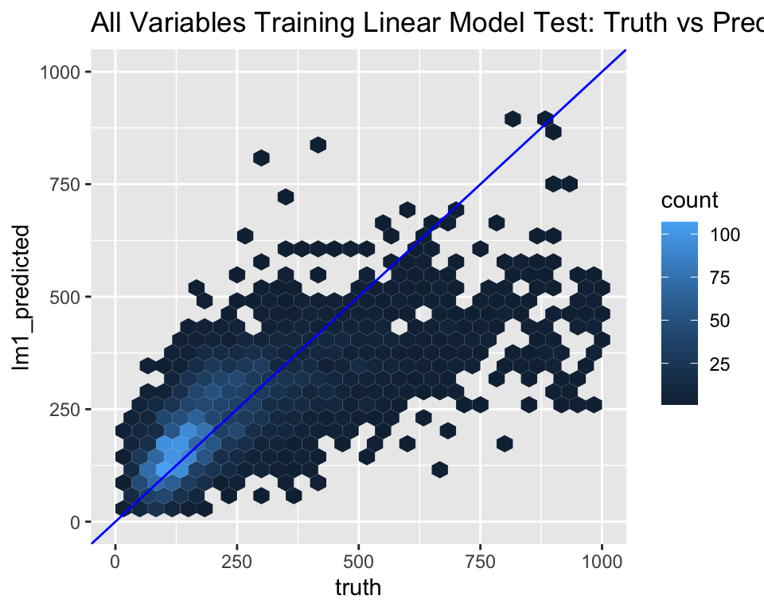

```r
if(show){

ggplot(data = results_train, aes(x = truth, y = lm1_predicted)) + #train
       geom_hex() +
       xlim(0,1000) + ylim(0,1000) +
       geom_abline(color = "red") +
       ggtitle("All Variables Training Linear Model Train: Truth vs Predicted")
ggplot(data = results_test, aes(x = truth, y = lm1_predicted)) + #test
       geom_hex() +
       xlim(0,1000) + ylim(0,1000) +
       geom_abline(color = "blue") +
       ggtitle("All Variables Training Linear Model Test: Truth vs Predicted")
}
```

## logged linear model

here we used the log transformed price variable. logging the variable attempts to linearize an exponential variable.

```r
lm_mod1_log <- lm(log_price ~ . -price,
              data = listings_train)

if(show) summary(lm_mod1_log)
##
## Call:
## lm(formula = log_price ~ . - price, data = listings_train)
##
## Residuals:
##      Min       1Q   Median       3Q      Max
## -2.30859 -0.28462 -0.01737  0.27182  1.79369
##
## Coefficients:
##                                                  Estimate   Std. Error t value
## (Intercept)                                   5.755284882  0.445335053  12.923
## host_response_timeN/A                         0.003780319  0.027478545   0.138
## host_response_timewithin a day                0.023347451  0.026562691   0.879
## host_response_timewithin a few hours         -0.144441553  0.026168591  -5.520
## host_response_timewithin an hour             -0.154322129  0.025763716  -5.990
## host_acceptance_rate                         -0.004875790  0.000211969 -23.002
## host_is_superhostt                            0.156225798  0.007978248  19.581
## host_listings_count                          -0.000008608  0.000023830  -0.361
## host_has_profile_pict                         0.026026692  0.067997402   0.383
## host_identity_verifiedt                       0.018941658  0.009127590   2.075
## neighbourhood_group_cleansedHonolulu          0.120425747  0.010626044  11.333
## neighbourhood_group_cleansedKauai             0.340328897  0.011993627  28.376
## neighbourhood_group_cleansedMaui              0.379007233  0.009936831  38.142
## room_typeHotel room                           0.143815385  0.044544084   3.229
## room_typePrivate room                        -0.198478723  0.014842684 -13.372
## room_typeShared room                         -1.105477374  0.087088230 -12.694
## accommodates                                  0.082316093  0.003119198  26.390
## bathrooms                                     0.222032751  0.007029332  31.587
## beds                                          0.025631490  0.004256316   6.022
## minimum_nights                               -0.000689793  0.001499284  -0.460
## maximum_nights                                0.000076554  0.000010654   7.186
## minimum_minimum_nights                       -0.003264144  0.001299735  -2.511
## maximum_minimum_nights                       -0.000801551  0.000125271  -6.399
## minimum_maximum_nights                       -0.000112353  0.000016489  -6.814
## maximum_maximum_nights                       -0.000063275  0.000031824  -1.988
## minimum_nights_avg_ntm                        0.000024665  0.001312820   0.019
## maximum_nights_avg_ntm                        0.000094685  0.000036073   2.625
## has_availabilityt                            -1.076483493  0.439160978  -2.451
## availability_30                               0.003475429  0.000859015   4.046
## availability_60                               0.003224040  0.000820270   3.930
## availability_90                              -0.002571031  0.000468234  -5.491
## availability_365                             -0.000137254  0.000041827  -3.281
## number_of_reviews                            -0.000269981  0.000105123  -2.568
## number_of_reviews_ltm                        -0.007517272  0.000644336 -11.667
## number_of_reviews_l30d                       -0.025442081  0.009546933  -2.665
## instant_bookablet                             0.072730966  0.008679387   8.380
## calculated_host_listings_count                0.007830659  0.002075180   3.773
## calculated_host_listings_count_entire_homes  -0.007657618  0.002075487  -3.690
## calculated_host_listings_count_private_rooms  0.007313479  0.002422835   3.019
## calculated_host_listings_count_shared_rooms  -0.024918050  0.016199096  -1.538
## host_since_days                              -0.000013186  0.000004832  -2.729
## name_sentiment                               -0.088225813  0.015636872  -5.642
## description_sentiment                         0.280410335  0.025538789  10.980
## neighborhood_overview_sentiment               0.027990210  0.021444081   1.305
## host_about_sentiment                         -0.011175760  0.019157509  -0.583
##                                                          Pr(>|t|)
## (Intercept)                                  < 0.0000000000000002 ***
## host_response_timeN/A                                    0.890579
## host_response_timewithin a day                           0.379438
## host_response_timewithin a few hours            0.000000034503094 ***
## host_response_timewithin an hour                0.000000002145351 ***
## host_acceptance_rate                         < 0.0000000000000002 ***
## host_is_superhostt                           < 0.0000000000000002 ***
## host_listings_count                                      0.717934
## host_has_profile_pict                                    0.701903
## host_identity_verifiedt                                  0.037983 *
## neighbourhood_group_cleansedHonolulu         < 0.0000000000000002 ***
## neighbourhood_group_cleansedKauai            < 0.0000000000000002 ***
## neighbourhood_group_cleansedMaui             < 0.0000000000000002 ***
## room_typeHotel room                                      0.001246 **
## room_typePrivate room                        < 0.0000000000000002 ***
## room_typeShared room                         < 0.0000000000000002 ***
## accommodates                                 < 0.0000000000000002 ***
## bathrooms                                    < 0.0000000000000002 ***
## beds                                            0.000000001761135 ***
## minimum_nights                                           0.645464
## maximum_nights                                  0.000000000000699 ***
## minimum_minimum_nights                                   0.012035 *
## maximum_minimum_nights                          0.000000000161289 ***
## minimum_maximum_nights                          0.000000000009840 ***
## maximum_maximum_nights                                   0.046799 *
## minimum_nights_avg_ntm                                   0.985011
## maximum_nights_avg_ntm                                   0.008678 **
## has_availabilityt                                        0.014248 *
## availability_30                                 0.000052386793815 ***
## availability_60                                 0.000085145399753 ***
## availability_90                                 0.000000040605053 ***
## availability_365                                         0.001035 **
## number_of_reviews                                        0.010231 *
## number_of_reviews_ltm                        < 0.0000000000000002 ***
## number_of_reviews_l30d                                   0.007708 **
## instant_bookablet                            < 0.0000000000000002 ***
## calculated_host_listings_count                           0.000162 ***
## calculated_host_listings_count_entire_homes              0.000225 ***
## calculated_host_listings_count_private_rooms             0.002544 **
## calculated_host_listings_count_shared_rooms              0.124011
## host_since_days                                          0.006366 **
## name_sentiment                                  0.000000017081341 ***
## description_sentiment                        < 0.0000000000000002 ***
## neighborhood_overview_sentiment                          0.191822
## host_about_sentiment                                     0.559658
## ---
## Signif. codes:  0 '***' 0.001 '**' 0.01 '*' 0.05 '.' 0.1 ' ' 1
##
## Residual standard error: 0.4376 on 15756 degrees of freedom
## Multiple R-squared:  0.5508, Adjusted R-squared:  0.5495
## F-statistic:   439 on 44 and 15756 DF,  p-value: < 0.00000000000000022
```

### lm_log predictions

here predictions are made just like the predictions made previously except this time we just add it as a new row to the data frame and exponentiate the data going into it. by using exp() the predictions are in real dollars.

```r
preds_train_lm1_log <- predict(lm_mod1_log, newdata = listings_train) %>% exp()
preds_test_lm1_log <- predict(lm_mod1_log, newdata = listings_test) %>% exp()

results_train$lm1_log_predicted = preds_train_lm1_log

results_test$lm1_log_predicted = preds_test_lm1_log

rm(preds_train_lm1_log)
rm(preds_test_lm1_log)
```

### lm_log metrics

```r
metrics(results_train, lm1_log_predicted, truth)
```

| .metric | .estimator | .estimate |
| --- | --- | --- |
| rmse | standard | 129.6231559 |
| rsq | standard | 0.4223683 |
| mae | standard | 78.5310054 |

```r
metrics(results_test, lm1_log_predicted, truth)
```

| .metric | .estimator | .estimate |
| --- | --- | --- |
| rmse | standard | 143.9238377 |
| rsq | standard | 0.3813389 |
| mae | standard | 83.6922424 |

### lm_log plotting truth vs predicted

these plots show that the models don’t suffer from the same problems where the data is consistently under-predicted, but it does have a higher spread the predictions ar all over the place. if anything, there is a bit of underprediction, but it is nothing like where it is extremely obvious

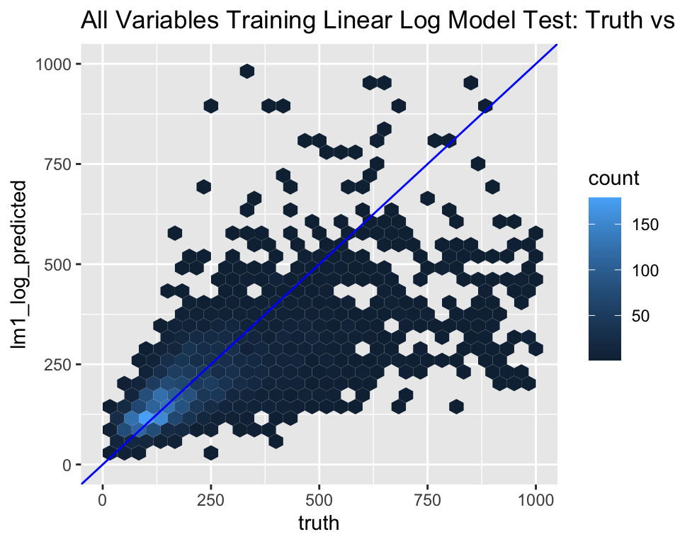

```r
if(show){

ggplot(data = results_train, aes(x = truth, y = lm1_log_predicted)) + #train
       geom_hex() +
       xlim(0,1000) + ylim(0,1000) +
       geom_abline(color = "red") +
       ggtitle("All Variables Training Linear Log Model Train: Truth vs Predicted")
ggplot(data = results_test, aes(x = truth, y = lm1_log_predicted)) + #test
       geom_hex() +
       xlim(0,1000) + ylim(0,1000) +
       geom_abline(color = "blue") +
       ggtitle("All Variables Training Linear Log Model Test: Truth vs Predicted")

}
```

## elastic net (enet) models

in this first chunk we just introduce a useful function to extract the best alpha value.

```r
get_alpha <- function(fit) {
  alpha <- fit$alpha
  error <- sapply(fit$modlist,
                  function(mod) {min(mod$cvm)})
  alpha[which.min(error)]
}
```

### enet model

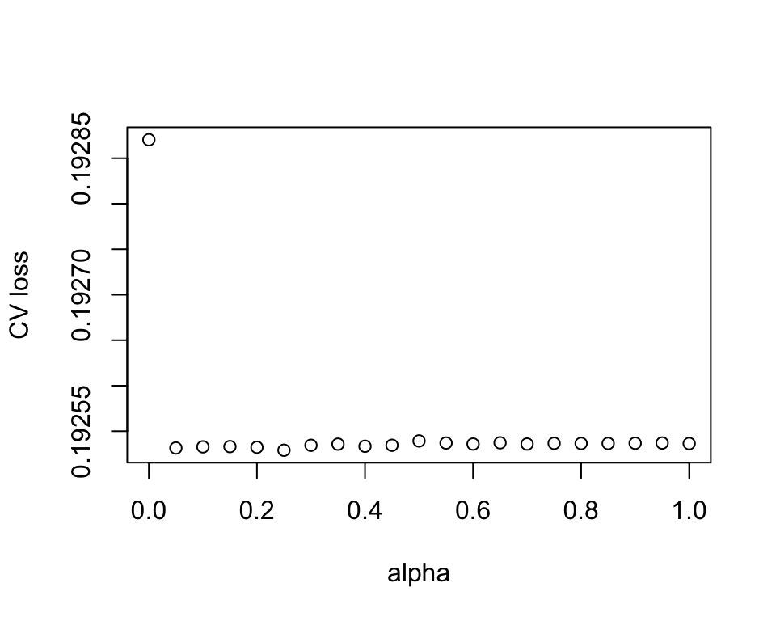

```r
enet_mod <- cva.glmnet(log_price ~ . -price,
                       data = listings_train,
                       alpha = seq(0,1, by = 0.05))
if(show) print(enet_mod)
## Call:
## cva.glmnet.formula(formula = log_price ~ . - price, data = listings_train,
##     alpha = seq(0, 1, by = 0.05))
##
## Model fitting options:
##     Sparse model matrix: FALSE
##     Use model.frame: FALSE
##     Alpha values: 0 0.05 0.1 0.15 0.2 0.25 0.3 0.35 0.4 0.45 0.5 0.55 0.6 0.65 0.7 0.75 0.8 0.85 0.9 0.95 1
##     Number of crossvalidation folds for lambda: 10

if(show) minlossplot(enet_mod, cv.type = "min")
```

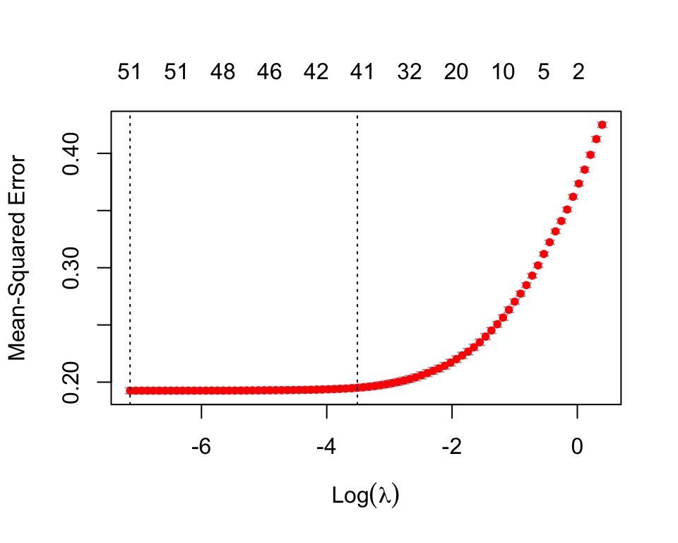

[interactive chart not shown]

```r
best_alpha <- get_alpha(enet_mod) #alpha = 1, lasso
                                    #alpha = 0, ridge

best_enet_mod <- cv.glmnet(log_price ~ . - price,
                           data = listings_train,
                           alpha = best_alpha)

if(show) {
  plot(best_enet_mod)
  coefpath(best_enet_mod)
}
```

### enet predictions

here we make predicitons. because we are using log we exp() the prices when we predict them. we also use the lambda1se to do some regularization.

```r
preds_train_enet <- predict(best_enet_mod, s = best_enet_mod$lambda.1se, listings_train, type = "response") %>% exp() %>% as.vector()
                                                                                                                    #idk why I had to add this when I have one results matrix for GLM
preds_test_enet <- predict(best_enet_mod, s = best_enet_mod$lambda.1se, listings_test, type = "response") %>% exp() %>% as.vector()

results_train$enet_predicted = preds_train_enet

results_test$enet_predicted = preds_test_enet

rm(preds_train_enet)
rm(preds_test_enet)
```

### enet metrics

here we see that the data still looks slightly over-fit. both the rmse and r^2 jump when the test data is used. the error rates are nearly identical to the lm_log model.

```r
metrics(results_train, enet_predicted, truth)
```

| .metric | .estimator | .estimate |
| --- | --- | --- |
| rmse | standard | 129.1994225 |
| rsq | standard | 0.4211197 |
| mae | standard | 78.5350537 |

```r
metrics(results_test, enet_predicted, truth)
```

| .metric | .estimator | .estimate |
| --- | --- | --- |
| rmse | standard | 142.0215734 |
| rsq | standard | 0.3842101 |
| mae | standard | 83.3643248 |

### enet plotting truth vs predicted

these plots look nearly identical to the lm_log model.

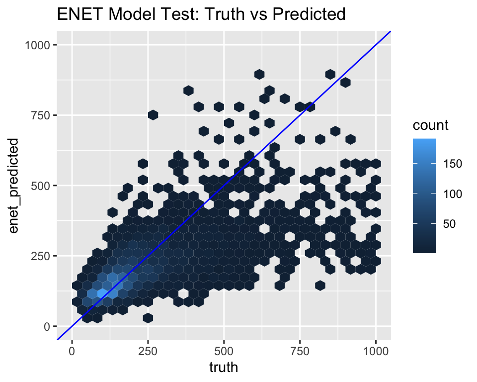

```r
if(show){

ggplot(data = results_train, aes(x = truth, y = enet_predicted)) + #train
       geom_hex() +
       xlim(0,1000) + ylim(0,1000) +
       geom_abline(color = "red") +
       ggtitle("ENET Model Train: Truth vs Predicted")
ggplot(data = results_test, aes(x = truth, y = enet_predicted)) + #test
       geom_hex() +
       xlim(0,1000) + ylim(0,1000) +
       geom_abline(color = "blue") +
       ggtitle("ENET Model Test: Truth vs Predicted")

}
```

## lasso model

### lasso making the model

here we make the lasso model with an alpha of 1 and use the log_price variable. we can possibly just get some minimized amount of variables. here we will use both the lambda min and 1se. the lambda min is used less for regularization and just variable reduction because we don’t face over-fitting in our regular linear model. with a model at lambda min the number of variables goes from 51 to 43 and then lambda 1se has 36 variables.

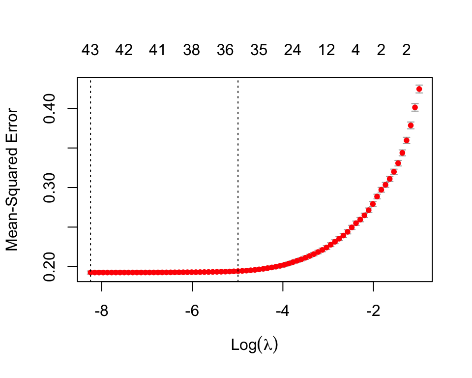

[interactive chart not shown]

```r
lasso_mod <- cv.glmnet(log_price ~ . -price,
                       data = listings_train,
                       alpha = 1)

if(show){
  print(lasso_mod)
  plot(lasso_mod)

  coefpath(lasso_mod)
}
## Call:
## cv.glmnet.formula(formula = log_price ~ . - price, data = listings_train,
##     alpha = 1)
##
## Model fitting options:
##     Sparse model matrix: FALSE
##     Use model.frame: FALSE
##     Number of crossvalidation folds: 10
##     Alpha: 1
##     Deviance-minimizing lambda: 0.0002621102  (+1 SE): 0.006801824
```

### lasso predictions

because we are using both levels of lambda we make predictions for both levels and then put them in the training and testing results dataframe.

```r
preds_train_lasso_1se <- predict(lasso_mod, s = lasso_mod$lambda.1se, listings_train, type = "response") %>% exp() %>% as.vector()
preds_test_lasso_1se <- predict(lasso_mod, s = lasso_mod$lambda.1se, listings_test, type = "response") %>% exp() %>% as.vector()

preds_train_lasso_min <- predict(lasso_mod, s = lasso_mod$lambda.min, listings_train, type = "response") %>% exp() %>% as.vector()
preds_test_lasso_min <- predict(lasso_mod, s = lasso_mod$lambda.min, listings_test, type = "response") %>% exp() %>% as.vector()

results_train$lasso_predicted_1se = preds_train_lasso_1se
results_test$lasso_predicted_1se = preds_test_lasso_1se

results_train$lasso_predicted_min = preds_train_lasso_min
results_test$lasso_predicted_min = preds_test_lasso_min

rm(preds_train_lasso_1se, preds_test_lasso_1se, preds_train_lasso_min, preds_test_lasso_min)
```

### lasso metrics

here we take a look at the metrics. across all of the regularized models the error metrics have stayed nearly the same. even at lambda.1se for lasso the error stays about the same with it being a bit over-fit still. a lasso model with lambda 1se would be good since it cuts out a lot of variables and can increase interpretability.

```r
metrics(results_train, lasso_predicted_1se, truth)
```

| .metric | .estimator | .estimate |
| --- | --- | --- |
| rmse | standard | 129.5248474 |
| rsq | standard | 0.4198348 |
| mae | standard | 78.5556721 |

```r
metrics(results_test, lasso_predicted_1se, truth)
```

| .metric | .estimator | .estimate |
| --- | --- | --- |
| rmse | standard | 142.6417842 |
| rsq | standard | 0.3831225 |
| mae | standard | 83.4438922 |

```r
metrics(results_train, lasso_predicted_min, truth)
```

| .metric | .estimator | .estimate |
| --- | --- | --- |
| rmse | standard | 129.8690952 |
| rsq | standard | 0.4205349 |
| mae | standard | 78.5526232 |

```r
metrics(results_test, lasso_predicted_min, truth)
```

| .metric | .estimator | .estimate |
| --- | --- | --- |
| rmse | standard | 143.7182880 |
| rsq | standard | 0.3821045 |
| mae | standard | 83.6353698 |

### lasso plotting truth vs predicted

here we just plotted the testing plots. the plots look nearly identical to the other regularized plots

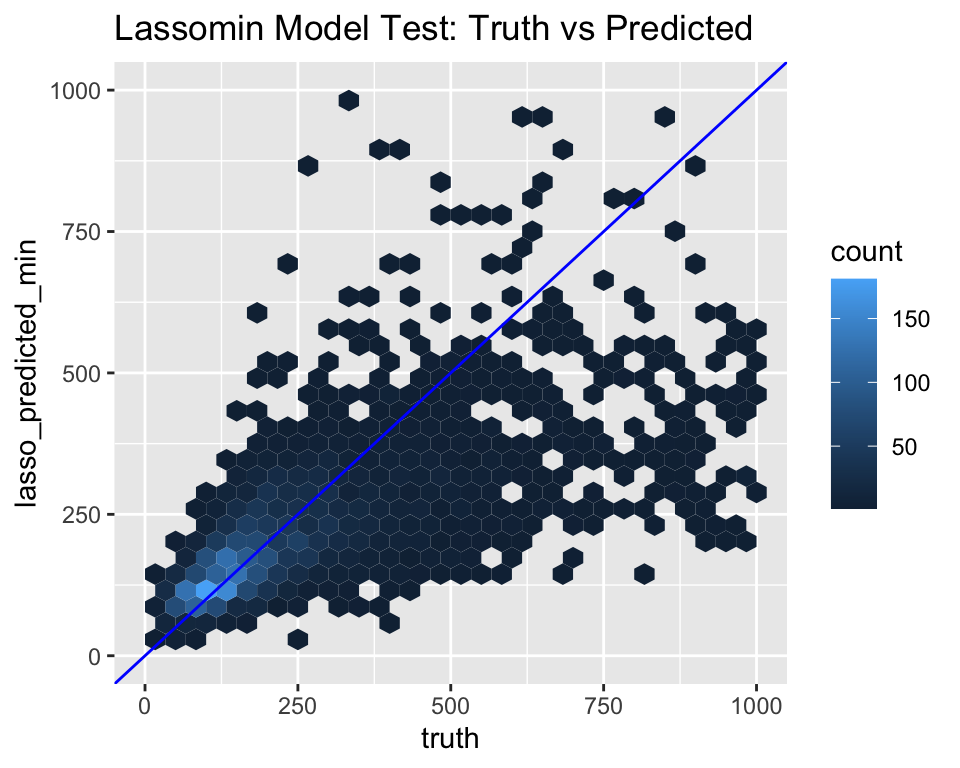

```r
if(show){

ggplot(data = results_test, aes(x = truth, y = lasso_predicted_1se)) +
       geom_hex() +
       xlim(0,1000) + ylim(0,1000) +
       geom_abline(color = "blue") +
       ggtitle("Lasso1se Model Test: Truth vs Predicted")
ggplot(data = results_test, aes(x = truth, y = lasso_predicted_min)) +
       geom_hex() +
       xlim(0,1000) + ylim(0,1000) +
       geom_abline(color = "blue") +
       ggtitle("Lassomin Model Test: Truth vs Predicted")

}
```

## random forests

### rf model

here we modify the data to include a variable that says if it is luxury or not. we set this to $285 because that is in the last quartile for price. this is a binary variable set into a new dataframe as a factor. in our random forest we set the outcome to be the binary variable luxury and took away the price and log_price because if we used those that would be cheating. we set the number of variables to the standard variable count for random forests. also we set the number of trees to 60 because when it was higher that is where the error started to level off. we do a varImpPlot to show how important variables are in the prediction. specifically we set it to where it shows the mean decrease in accuracy or the % increase in MSE.

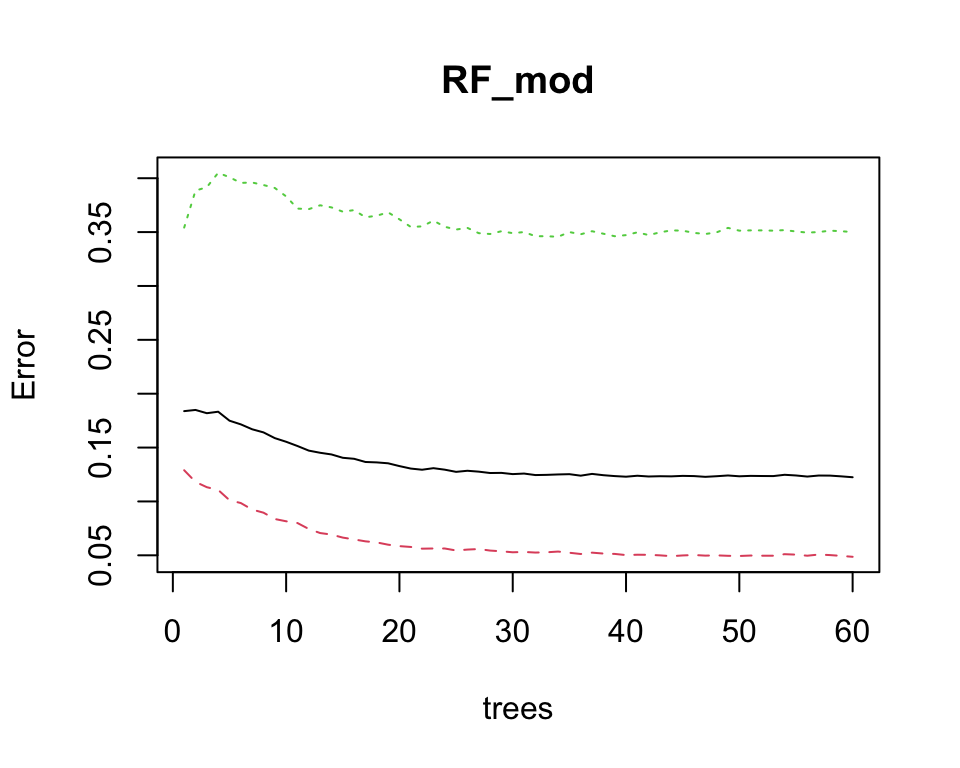

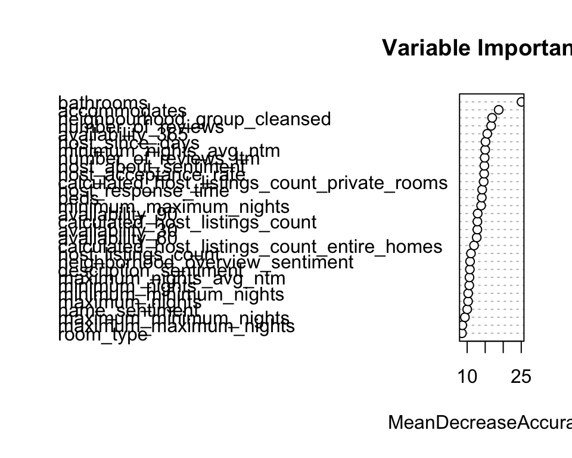

```
##                                                       f         t
## host_response_time                           12.0836730 13.683059
## host_acceptance_rate                         13.6341753 13.971278
## host_is_superhost                             6.1456610  6.359988
## host_listings_count                           9.5660605 10.512149
## host_has_profile_pic                          0.0000000  1.438301
## host_identity_verified                        4.9644986  3.328006
## neighbourhood_group_cleansed                 15.9970921 12.855579
## room_type                                     5.1201310  6.055667
## accommodates                                 15.2315617 17.567571
## bathrooms                                    19.7826418 19.565067
## beds                                         11.0874251 13.233775
## minimum_nights                                8.4852346 11.415393
## maximum_nights                                8.6403929  8.708939
## minimum_minimum_nights                        9.3932770  7.524162
## maximum_minimum_nights                        8.8823534  7.623280
## minimum_maximum_nights                       10.1460430  7.859227
## maximum_maximum_nights                        7.1003096  9.805195
## minimum_nights_avg_ntm                       12.4066291 13.833069
## maximum_nights_avg_ntm                        7.9666337  8.488104
## has_availability                              0.0000000  0.000000
## availability_30                              11.1694866  5.853142
## availability_60                              10.2068812  7.498778
## availability_90                              10.9506630  5.413322
## availability_365                             13.1716134  7.897878
## number_of_reviews                            11.5527015 13.985290
## number_of_reviews_ltm                         9.4128481 11.401046
## number_of_reviews_l30d                        0.6644186 -1.439464
## instant_bookable                              5.4957174  4.485941
## calculated_host_listings_count               10.0665290 10.771842
## calculated_host_listings_count_entire_homes   9.7066222 13.293263
## calculated_host_listings_count_private_rooms 11.1056033 11.869670
## calculated_host_listings_count_shared_rooms   2.7663854  2.632482
## host_since_days                              12.3494377 12.925767
## name_sentiment                                7.4209165  7.915744
## description_sentiment                         7.7867098  6.011024
## neighborhood_overview_sentiment               7.1612467  7.866687
## host_about_sentiment                         12.0522151 11.854521
##                                              MeanDecreaseAccuracy
## host_response_time                                     14.1614634
```

[output cut: 59 more lines]

```
## availability_90                                  168.33304192
## availability_365                                 205.41919461
## number_of_reviews                                257.88778415
## number_of_reviews_ltm                            177.15467767
## number_of_reviews_l30d                             7.72183608
## instant_bookable                                  19.31842614
## calculated_host_listings_count                   164.64846268
## calculated_host_listings_count_entire_homes      161.98108950
## calculated_host_listings_count_private_rooms      62.02110194
## calculated_host_listings_count_shared_rooms        2.45538097
## host_since_days                                  204.29348198
## name_sentiment                                   175.87170459
## description_sentiment                            260.16125507
## neighborhood_overview_sentiment                  132.64604306
## host_about_sentiment                             162.89453839
```

```r
listings_train_RF <- listings_train
listings_test_RF <- listings_test

listings_train_RF$luxury <- with(listings_train_RF, ifelse(price>285, 't','f' )) %>% as.factor()
listings_test_RF$luxury <- with(listings_test_RF, ifelse(price>285, 't','f' )) %>% as.factor()

RF_mod <- randomForest(luxury ~ . -price -log_price,
                       data = listings_train_RF,
                       type = classification,
                       mtry = sqrt(40),
                       ntree = 60,
                       importance = TRUE)
if(show) {
  plot(RF_mod)
  varImpPlot(RF_mod, main = "Variable Importance", type = 1)
  importance(RF_mod)
}
```

### rf predictions

here we make some predictions with the model using the modified data. next we made a new data frame to use these new predictions against the truth.

```r
preds_train_RF <- predict(RF_mod, listings_train_RF)
preds_test_RF <- predict(RF_mod, listings_test_RF)

results_train_RF <- data.frame(
  'predicted' = preds_train_RF,
  'truth' = listings_train_RF$luxury
  )

results_test_RF <- data.frame(
  'predicted' = preds_test_RF,
  'truth' = listings_test_RF$luxury
  )

rm(preds_test_RF, preds_train_RF)
```

### rf true vs false

```r
RF_train_conf <- conf_mat(results_train_RF,
         truth = truth,
         estimate = predicted)

RF_test_conf <- conf_mat(results_test_RF,
         truth = truth,
         estimate = predicted)

print(RF_train_conf)
##           Truth
## Prediction     f     t
##          f 11926    10
##          t     4  3861
print(RF_test_conf)
##           Truth
## Prediction    f    t
##          f 2792  357
##          t  126  674

#train accuracy
(11928 + 3862) / (11928 + 3862 + 9 + 2)
## [1] 0.9993038
#test accuracy
(2787 + 677) / (2787 + 677 + 354 + 131)
## [1] 0.8771841

#train true positive rate - sensitivity
(11928) / (11928 + 9)
## [1] 0.999246
#test true positive rate - sensitivity
(2787) / (2787 + 354)
## [1] 0.887297

#train true negative rate - specificity
(3862) / (3862 + 2)
## [1] 0.9994824
#test true negative rate - specificity
(677) / (677 + 131)
## [1] 0.8378713
```